# Text Mining approach to analyze news articles

Mateusz Cedro Jan Dudzik Weronika Kalita

Feb 2023

## Introduction

The 2018 FIFA World Cup, which was held in Russia, was one of the most anticipated events in the sports world, with millions of fans around the globe sharing their thoughts and emotions on social media platforms such as Twitter. By using text mining techniques, we aim to analyze the tweets dataset, by identifying the most common tweets topics, and grouping them into clusters. The aim of this project is to provide valuable insights into the social media landscape surrounding the 2018 World Cup, and how fans engaged with the tournament.

### 2. Data

For this task, we have chosen the FIFA World Cup 2018 Tweets dataset from kaggle (source https://www.kaggle.com/datasets/rgupta09/world-cup-2018-tweets), which consists of approximately 530 000 tweets from 2018 Football World Cup. The tweets were gathered between start of Round of 16, and Final. The dataset was already pre-processed, including removing users, websites, hashtags, mentions, special characters or retweet information from tweet’s body. Duplicates were removed and some of the shortenings, like “n’t”, “’ll” etc. were replaced with their proper full-word form.

In our analysis, we have started with randomly selecting just 5% of the whole dataset, removed stopwords, uppercase letters, punctuation and numbers, resulting with following graph of top words.

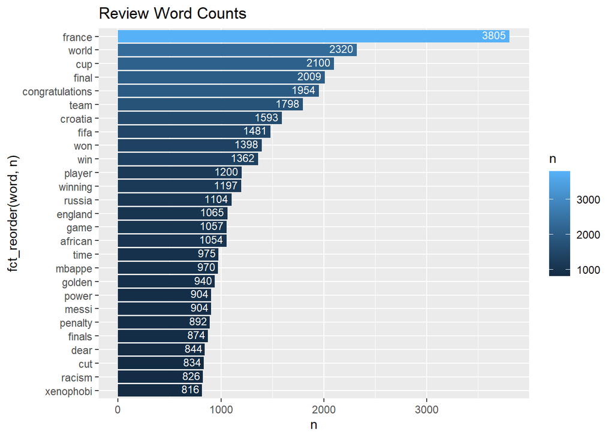

[figure not shown]

### 3. Modeling

In order to achieve our goals within this project, we will use two common text mining techniques. First one will be to cluster using hierarchical clustering with Ward’s method, and K-means algorithm. When it comes to topic modeling, the Latent Dirichlet Allocation was performed. Latent Dirichlet Allocation (LDA) is a generative probabilistic model for collections of discrete data, such as text corpora. It assumes that each document in a corpus is a mixture of latent topics, and each topic is characterized by a distribution over words. LDA aims to find the underlying topics in a corpus of documents by estimating the topic distributions and word distributions. The main idea behind LDA is that it tries to discover the hidden topics in the text data by observing the word frequencies in the documents and constructing a probability distribution over topics for each document. LDA is widely used in natural language processing and information retrieval for tasks such as topic modeling, document classification, and clustering.

### 4. Evaluation (quality of obtained results)

We have started with clustering the tweets with hierarchical clustering and K-means.

[figure not shown]

```
##   cluster size                                          top_words
## 1       1 1331                   final, france, team, goal, today
## 2       2   54          golden, golden_ball, ball, mbappe, kylian
## 3       3   34 finals, quarter, quarter_finals, semi, semi_finals
## 4       4   15           power, exo, power_power, power_exo, play
## 5       5   30       home, coming, coming_home, brought, football
```

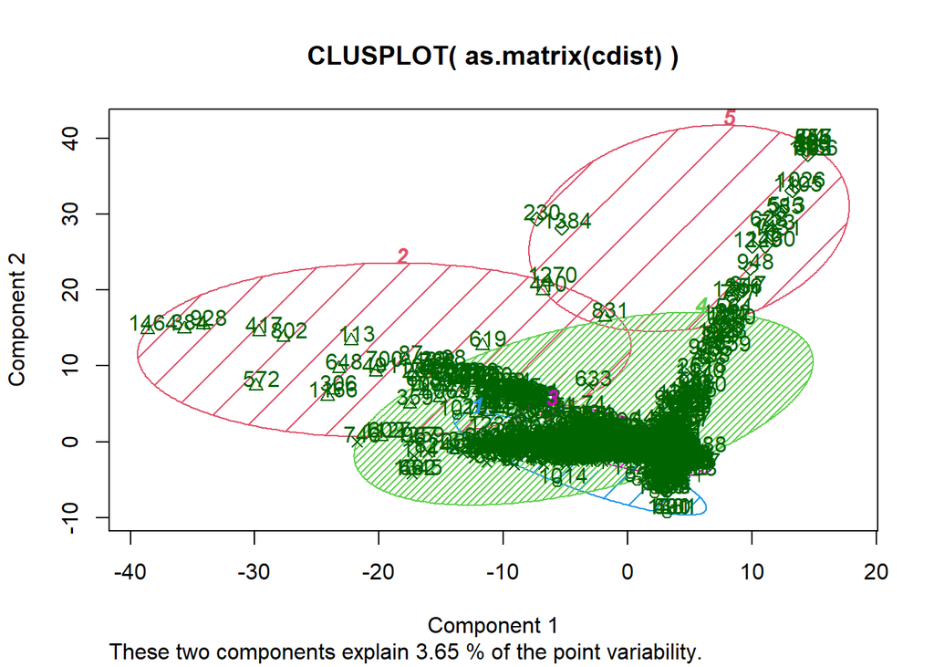

Let’s move to the LDA method. Following parameters were considered:

- Alpha – document-topic density; the higher alpha is, documents are made of more topics
- Beta – topic-word density; the higher beta is, topics are made of more words in the corpus
- Number of topics – to be extracted from the corpus
- Number of topic terms – composed in a single topic

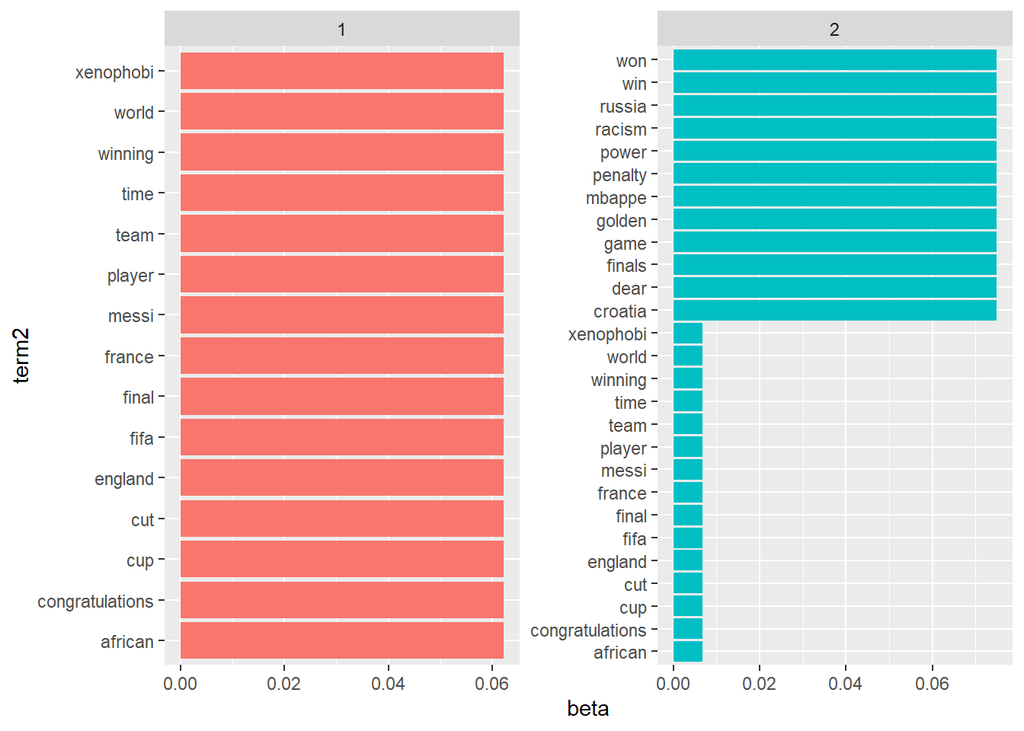

With the use ob basic LDA algorithm, we can see main topics and tags within the topics across all tweets.

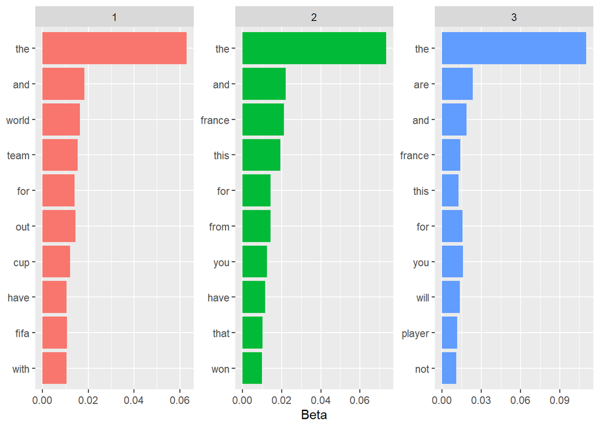

Chart above represents most commonly used words for three topics. As we can see, in this part of analysis we still do include the stop words, so in next step, we will exclude those and stem the words to their basic form.

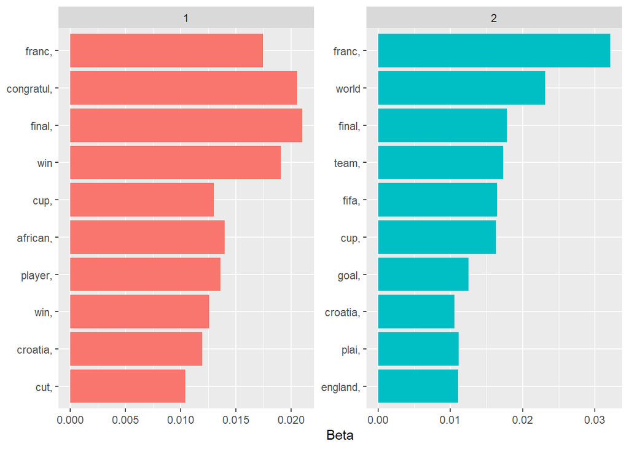

### 5. Summary

Given such a huge data set (530 000 tweets), it is essential to somehow find underlying patterns and stack or combine similarly behaving information into more common groups. Therefore we have used the hierarchical clustering algorithm, which bases on the similarity distance metrics, to overcome the problem of huge data sets inference. After performing the clustering algorithms, we have performed the analysis of the main topics, and proposed the 2-dimensional representations of the clustered tweets. Further on, with the use of LDA text mining method, we have modeled main topics with regard to tweets from World Cup 2018. Initially dataset consisted of 530 000 tweets which was much too much, therefore we sampled randomly 5% of the tweets which result in 26 500 tweets in total to the analysis.